# R Notebook

#Libraries

```r
library(mosaic)
```

Supervised vs unsupervised models

Supervised Unsupervised

What outcome do they want from the model?

# Variable Engineering

What can we do to columns in a dataset that make them better for modelling?

I want to make a model but… My data has missing values - we might impute them if appropriate, but might drop them if inappropriate My data has a couple of serious outliers - we’d need to justify dropping them My data is hightly-right skewed - we’d transform the variable e.g. using log My data is categorical - we’d encode using dummy variables My data has too many unique values - we’d group them together in bins to reduce granularity My data doesn’t have the best predictors - we’d derive better ones My data has variables that are measured in different units - we’d consider scaling

Garbage in –> Garbage out Less garbage in –> less garbage out

## Missing values

- keep (may not be an option for some modelling)
- drop
- impute (replace with something meaningful)

```r
grades <- read_csv("data/grades.csv") %>% janitor::clean_names()
```

```r
#look for missing values
summary(grades)
```

[output not shown]

```r
grades <- grades %>%
  mutate(across(where(is.double), ~coalesce(.x, mean(.x, na.rm = TRUE))))
```

Imputing missing values can be valuable for modelling as it: -retains the information from other predictors -doesn’t ‘throw off’ the regression too much if we use ‘sensible’ values to impute with

## Dealing with outliers

- doen’t be hasty to drop data that looks like it doesn’t fit in with the rest and be sure to justify the removal of outliers.

## Transformations

- China and India have massive populations, so when plotting all the countries and colouring in based on population, we only saw two groups.

When we’ve got very skewed data, one strategy is to transform the variable: -usually this means using the variable itself. (e.g. multiplying it by itself) -We can reduce the effect of skew by taking exponents or logs for left/right skew -can also square or sqrt

e.g. before: gdp = -9 * population + 90 after: gdp = 2.3 * log(population) + 90

a way to convert non-linear relationships into linear relationships -a common one is to take logs of prices/financial data which tends to be right-skewed

## Categorical data in a model

-Convert into a wide format where each categorical level is a variable (we turn them into switches) - if maths is switched on, what will the final grade be? - if english is switched on, what will the final grade be? (parallel slopes model)

If maths, physics, french, and biology are 0, we know english must be 1

Dummy variable trap - we don’t want to have the same information in our model twice.

variable that should have a ‘weight’ of 1, a weight of 2

multicollinearity - having a copy of a variable in a model

So having both temperature in celsius and temperature in fahrenheight in a model

ice_cream = slope * temperature, slope * avg_temperature_fahrenheit + intercept

How we’d actually do dummy variables: 1. In R, we woudln’t. (R does dummies automatically when using ‘lm’ or ‘glm’ …) 2. If we had to, we’d use a package:

```r
grades_dummies <- grades %>%
  fastDummies::dummy_cols(
    select_columns = "subject",
    remove_first_dummy = TRUE, #to avoid the multicollinearity/dummy variable trap
    remove_selected_columns = TRUE
  )
grades_dummies
```

| assignment | tutorial | midterm | take_home | final | subject_english | subject_french | subject_maths | subject_physics |
| --- | --- | --- | --- | --- | --- | --- | --- | --- |
| 57.14 | 34.09 | 64.38 | 51.48000 | 52.50000 | 1 | 0 | 0 | 0 |
| 95.05 | 105.49 | 67.50 | 99.07000 | 68.33000 | 0 | 0 | 0 | 1 |
| 83.70 | 83.17 | 30.00 | 63.15000 | 48.89000 | 0 | 0 | 0 | 1 |
| 81.22 | 96.06 | 49.38 | 105.93000 | 80.56000 | 0 | 0 | 1 | 0 |
| 91.32 | 93.64 | 95.00 | 107.41000 | 73.89000 | 0 | 0 | 0 | 1 |
| 95.00 | 92.58 | 93.12 | 97.78000 | 68.06000 | 0 | 0 | 1 | 0 |
| 95.05 | 102.99 | 56.25 | 99.07000 | 50.00000 | 0 | 0 | 0 | 1 |
| 72.85 | 86.85 | 60.00 | 80.82847 | 56.11000 | 0 | 0 | 1 | 0 |
| 84.26 | 93.10 | 47.50 | 18.52000 | 50.83000 | 0 | 0 | 0 | 1 |
| 90.10 | 97.55 | 51.25 | 88.89000 | 63.61000 | 0 | 0 | 1 | 0 |

[output cut: 89 more lines]

#### We might want to group together low frequency categories

```r
grades %>%
  mutate(subject = if_else(subject %in% c("maths", "physics"), subject, "other"))
```

## Binning data

Sometimes, it’s useful to group together continuous predictors

```r
grades %>%
  distinct(midterm) %>%
  nrow()
```

```
[1] 64
```

-> grade category (the letter grade)

> 70 = A > 60 = B > 50 = C

```r
grades %>%
  mutate(letter_grade = case_when(
    midterm >= 70 ~ "A",
    midterm >= 60 ~ "B",
    midterm >= 50 ~ "C",
    TRUE ~ "F"
  ))
```

| subject | assignment | tutorial | midterm | take_home | final | letter_grade |
| --- | --- | --- | --- | --- | --- | --- |
| english | 57.14 | 34.09 | 64.38 | 51.48000 | 52.50000 | B |
| physics | 95.05 | 105.49 | 67.50 | 99.07000 | 68.33000 | B |
| physics | 83.70 | 83.17 | 30.00 | 63.15000 | 48.89000 | F |
| maths | 81.22 | 96.06 | 49.38 | 105.93000 | 80.56000 | F |
| physics | 91.32 | 93.64 | 95.00 | 107.41000 | 73.89000 | A |
| maths | 95.00 | 92.58 | 93.12 | 97.78000 | 68.06000 | A |
| physics | 95.05 | 102.99 | 56.25 | 99.07000 | 50.00000 | C |
| maths | 72.85 | 86.85 | 60.00 | 80.82847 | 56.11000 | B |
| physics | 84.26 | 93.10 | 47.50 | 18.52000 | 50.83000 | F |
| maths | 90.10 | 97.55 | 51.25 | 88.89000 | 63.61000 | C |

[output cut: 89 more lines]

Sometimes we want to reduce the granularity. In these cases, we’d group together observations into bins

-count() to determine how many observations for each category in a categorical variable -histograms of continuous variables -correlations of continuous variables -boxplots of categorical variables

‘ggpairs()’

## Deriving variables

We call the initial data variables when we load them in: raw variables

any columns we create are ‘derived variables’ - these can be very useful.

| Sepal.Length | Sepal.Width | Petal.Length | Petal.Width | Species | petal_ratio |
| --- | --- | --- | --- | --- | --- |
| 5.1 | 3.5 | 1.4 | 0.2 | setosa | 7.000000 |
| 4.9 | 3.0 | 1.4 | 0.2 | setosa | 7.000000 |
| 4.7 | 3.2 | 1.3 | 0.2 | setosa | 6.500000 |
| 4.6 | 3.1 | 1.5 | 0.2 | setosa | 7.500000 |
| 5.0 | 3.6 | 1.4 | 0.2 | setosa | 7.000000 |
| 5.4 | 3.9 | 1.7 | 0.4 | setosa | 4.250000 |
| 4.6 | 3.4 | 1.4 | 0.3 | setosa | 4.666667 |
| 5.0 | 3.4 | 1.5 | 0.2 | setosa | 7.500000 |
| 4.4 | 2.9 | 1.4 | 0.2 | setosa | 7.000000 |
| 4.9 | 3.1 | 1.5 | 0.1 | setosa | 15.000000 |

[output cut: 140 more lines]

## Scaling variables

Models don’t care about the units.

For example: on two different scales gdp = 1 * pop(m) + 50 gdp = 1000 * pop(100k) + 50

55 pop = 55 million people

so when we get very large values 20000 vs 2. OUr model doesnt’ account for context, it only cares about the values - so we need to know the measurement scale.

To bring our values onto a similar scale, we could scale them - standardisation (follows a standard normal distribution (mean 0, sd 1)) - normalisation (follows a normal distribution)

This isn’t particularly model-breaking for linear regression (just changes the interpretation), but can be for other models.

Our baseline our predictor is 0, this is our response.

When standardised our predictor is at its mean, this is our response

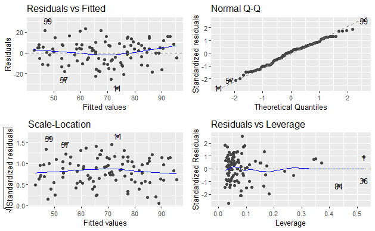

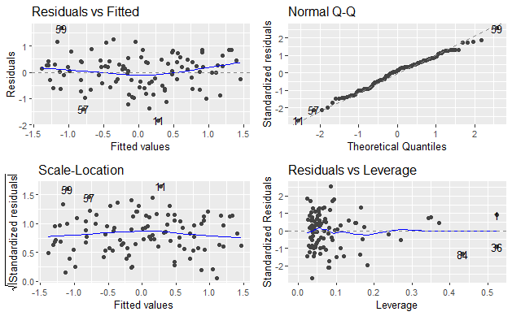

```r
summary(model_baseline)
```

```
Call:
lm(formula = final ~ ., data = grades)

Residuals:
    Min      1Q  Median      3Q     Max
-33.794  -8.593   1.924   7.853  31.014

Coefficients:
               Estimate Std. Error t value Pr(>|t|)
(Intercept)     0.72468   13.12123   0.055   0.9561
subjectenglish -6.66295   12.34646  -0.540   0.5908
subjectfrench   5.08663    8.76859   0.580   0.5633
subjectmaths    7.43131    7.68719   0.967   0.3363
subjectphysics  8.91328    7.62822   1.168   0.2457
assignment      0.06609    0.12832   0.515   0.6078
tutorial        0.03858    0.11771   0.328   0.7439
midterm         0.61227    0.07529   8.133 2.17e-12 ***
take_home       0.11633    0.06941   1.676   0.0972 .
---
Signif. codes:  0 ‘***’ 0.001 ‘**’ 0.01 ‘*’ 0.05 ‘.’ 0.1 ‘ ’ 1

Residual standard error: 12.66 on 90 degrees of freedom
Multiple R-squared:  0.5704,    Adjusted R-squared:  0.5323
F-statistic: 14.94 on 8 and 90 DF,  p-value: 1.033e-13
```

final_grade = … + 0.7 + (0.6 * midterm result)

```r
summary(model_scaled)
```

```
Call:
lm(formula = final ~ ., data = grades_scaled)

Residuals:
    Min      1Q  Median      3Q     Max
-1.8256 -0.4642  0.1040  0.4242  1.6754

Coefficients:
               Estimate Std. Error t value Pr(>|t|)
(Intercept)    -0.40572    0.39725  -1.021   0.3098
subjectenglish -0.35994    0.66698  -0.540   0.5908
subjectfrench   0.27479    0.47369   0.580   0.5633
subjectmaths    0.40145    0.41528   0.967   0.3363
subjectphysics  0.48151    0.41209   1.168   0.2457
assignment      0.04498    0.08733   0.515   0.6078
tutorial        0.03141    0.09584   0.328   0.7439
midterm         0.64088    0.07881   8.133 2.17e-12 ***
take_home       0.14886    0.08882   1.676   0.0972 .
---
Signif. codes:  0 ‘***’ 0.001 ‘**’ 0.01 ‘*’ 0.05 ‘.’ 0.1 ‘ ’ 1

Residual standard error: 0.6839 on 90 degrees of freedom
Multiple R-squared:  0.5704,    Adjusted R-squared:  0.5323
F-statistic: 14.94 on 8 and 90 DF,  p-value: 1.033e-13
```

The model hasn’t really changed, but our interpretation has been shifted though

# Multiple linear regression

## What’s different

y = mx + c

–

y = m1x1 + m2x2 + m3x3 + c

- rather than explaining the variation of y with one predictor (x), we’re going to allow for multiple predictors(X).

## The Plan

-Understand the business question -Build a simple linear model -add in another predictor -categorical predictor (the parallel slopes model) -add in another predictor -continuous predictor -look at interactions

## Data

| hightemp | lowtemp | avgtemp | spring | summer | fall | cloudcover | precip | volume | weekday | dayType |
| --- | --- | --- | --- | --- | --- | --- | --- | --- | --- | --- |
| 83 | 50 | 66.5 | 0 | 1 | 0 | 7.6 | 0.00 | 501 | TRUE | weekday |
| 73 | 49 | 61.0 | 0 | 1 | 0 | 6.3 | 0.29 | 419 | TRUE | weekday |
| 74 | 52 | 63.0 | 1 | 0 | 0 | 7.5 | 0.32 | 397 | TRUE | weekday |
| 95 | 61 | 78.0 | 0 | 1 | 0 | 2.6 | 0.00 | 385 | FALSE | weekend |
| 44 | 52 | 48.0 | 1 | 0 | 0 | 10.0 | 0.14 | 200 | TRUE | weekday |
| 69 | 54 | 61.5 | 1 | 0 | 0 | 6.6 | 0.02 | 375 | TRUE | weekday |
| 66 | 39 | 52.5 | 1 | 0 | 0 | 2.4 | 0.00 | 417 | TRUE | weekday |
| 66 | 38 | 52.0 | 1 | 0 | 0 | 0.0 | 0.00 | 629 | FALSE | weekend |
| 80 | 55 | 67.5 | 0 | 1 | 0 | 3.8 | 0.00 | 533 | FALSE | weekend |
| 79 | 45 | 62.0 | 0 | 1 | 0 | 4.1 | 0.00 | 547 | TRUE | weekday |

[output cut: 80 more lines]

|  | hightemp | lowtemp | avgtemp | spring | summer | fall | cloudcover | precip | volume | weekday | dayType |
| --- | --- | --- | --- | --- | --- | --- | --- | --- | --- | --- | --- |
| 1 | 83 | 50 | 66.5 | 0 | 1 | 0 | 7.6 | 0.00 | 501 | TRUE | weekday |
| 2 | 73 | 49 | 61.0 | 0 | 1 | 0 | 6.3 | 0.29 | 419 | TRUE | weekday |
| 3 | 74 | 52 | 63.0 | 1 | 0 | 0 | 7.5 | 0.32 | 397 | TRUE | weekday |
| 4 | 95 | 61 | 78.0 | 0 | 1 | 0 | 2.6 | 0.00 | 385 | FALSE | weekend |
| 5 | 44 | 52 | 48.0 | 1 | 0 | 0 | 10.0 | 0.14 | 200 | TRUE | weekday |
| 6 | 69 | 54 | 61.5 | 1 | 0 | 0 | 6.6 | 0.02 | 375 | TRUE | weekday |

Volume of users of a rail trail

## Question: Can we explain the variation in ‘bolume’ using other predictors

Candidate variables: -temp (F) -season -cloudcover (0 to 10) -precip (inches) -weekday (logical)

There are some issues with data (in it’s raw form): -spring: fall are numbers rather than logical TRUE/FALSE -some collinear predictors (we want predictors to be independent) -temps -weekday/day type -spring/summer/fall -season

## Variable Engineering

-drop collinear columns -convert column types -clean up the column names

```r
railtrail_trim <- RailTrail %>%
  janitor::clean_names() %>%
  mutate(across(spring:fall, as.logical)) %>%
  select(-c(lowtemp, hightemp, fall, day_type))

head(railtrail_trim)
```

|  | avgtemp | spring | summer | cloudcover | precip | volume | weekday |
| --- | --- | --- | --- | --- | --- | --- | --- |
| 1 | 66.5 | FALSE | TRUE | 7.6 | 0.00 | 501 | TRUE |
| 2 | 61.0 | FALSE | TRUE | 6.3 | 0.29 | 419 | TRUE |
| 3 | 63.0 | TRUE | FALSE | 7.5 | 0.32 | 397 | TRUE |
| 4 | 78.0 | FALSE | TRUE | 2.6 | 0.00 | 385 | FALSE |
| 5 | 48.0 | TRUE | FALSE | 10.0 | 0.14 | 200 | TRUE |
| 6 | 61.5 | TRUE | FALSE | 6.6 | 0.02 | 375 | TRUE |

### Detect Perfect Collinearity (column aliases)

```r
alias(volume ~ ., RailTrail)
```

```
Model :
volume ~ hightemp + lowtemp + avgtemp + spring + summer + fall +
    cloudcover + precip + weekday + dayType

Complete :
               (Intercept) hightemp lowtemp spring summer cloudcover precip weekdayTRUE
avgtemp          0         1/2      1/2       0      0      0          0      0
fall             1           0        0      -1     -1      0          0      0
dayTypeweekend   1           0        0       0      0      0          0     -1
```

```r
alias(volume ~ ., railtrail_trim)
```

```
Model :
volume ~ avgtemp + spring + summer + cloudcover + precip + weekday
```

Pairs plot - a tool for examining predictors Plots every variable against one another 1. correlations 2. distribution of each - boxplots (boxes to be different for different categorical levels) 3. scatter plots (any discernable pattern)

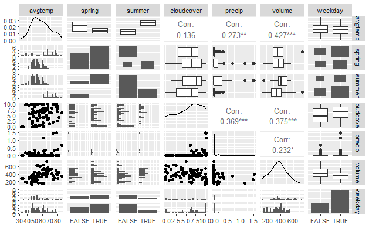

Avg temperature has the highest correlation, so let’s start with that.

y = intercept + m_avg_temp * avg_temp

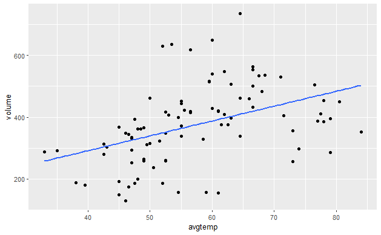

There does appear to be a linear relationship between volume and avg temp (as temp increases, so does the volume of users on the rail trail)

## Goodness of fit metrics

- $r^2$: coefficient of determination (1 = perfect, 0 = perfectly imperfect)
- standard error in the residuals - how far are the residuals from the line / how far on avg do the fitted values differ from the measured values? (same units as y - so since volume is measured in people, so is the standard error)

```r
summary(model)
```

```
Call:
lm(formula = volume ~ avgtemp, data = railtrail_trim)

Residuals:
    Min      1Q  Median      3Q     Max
-237.53  -80.00    8.49   55.14  326.67

Coefficients:
            Estimate Std. Error t value Pr(>|t|)
(Intercept)   99.602     63.474   1.569     0.12
avgtemp        4.802      1.084   4.428 2.72e-05 ***
---
Signif. codes:  0 ‘***’ 0.001 ‘**’ 0.01 ‘*’ 0.05 ‘.’ 0.1 ‘ ’ 1

Residual standard error: 115.9 on 88 degrees of freedom
Multiple R-squared:  0.1822,    Adjusted R-squared:  0.1729
F-statistic: 19.61 on 1 and 88 DF,  p-value: 2.723e-05
```

## Diagnostic Plots!

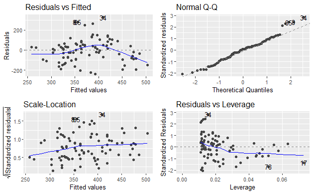

Check the regression assumptions. How well does this simple model perform in predicting volume?

mild heteroscedasticity - slight indication of a wedge shape

0.18 of the variation in volume is explained by avg temp (not much)

How can we improve the model? - Add more predictors

Because David said it might work… throw in weekday

## Adding a categorical predictor

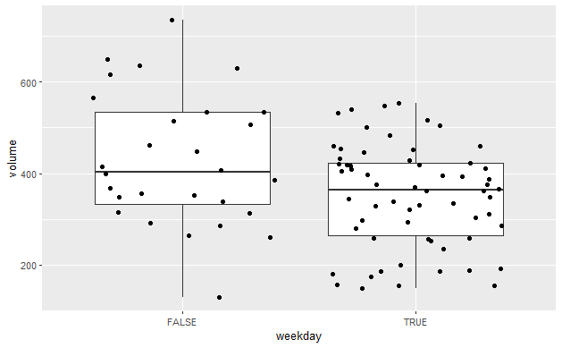

| cor |
| --- |
| -0.2932675 |

Some evidence that volume and weekday are related (there is a dependency)

y = intercept + (b_average_temp * avg temp) + (b_weekday * weekday)

```r
#patsy notation
formula <- volume ~ avgtemp + weekday
model_temp_wday <- lm(formula, railtrail_trim)
```

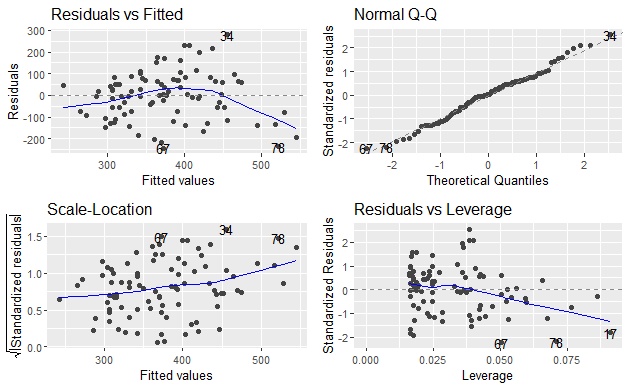

```r
summary(model_temp_wday)
```

```
Call:
lm(formula = formula, data = railtrail_trim)

Residuals:
    Min      1Q  Median      3Q     Max
-242.92  -75.72    3.15   66.90  280.06

Coefficients:
            Estimate Std. Error t value Pr(>|t|)
(Intercept)  163.022     65.428   2.492  0.01461 *
avgtemp        4.541      1.050   4.323 4.08e-05 ***
weekdayTRUE  -70.320     25.566  -2.751  0.00724 **
---
Signif. codes:  0 ‘***’ 0.001 ‘**’ 0.01 ‘*’ 0.05 ‘.’ 0.1 ‘ ’ 1

Residual standard error: 111.8 on 87 degrees of freedom
Multiple R-squared:  0.2476,    Adjusted R-squared:  0.2303
F-statistic: 14.32 on 2 and 87 DF,  p-value: 4.214e-06
```

Slight improvement on r2: Our model including avgtemp and weekday can explain 0.2476 of the total variation of volume

Also reduction in standard error

HOw should we interpret the value of the coeeficient for weekday TRUE? On weekdays, we would expect to see, on average, 70 fewer trail users compared to weekends (holding avgtemp constant)

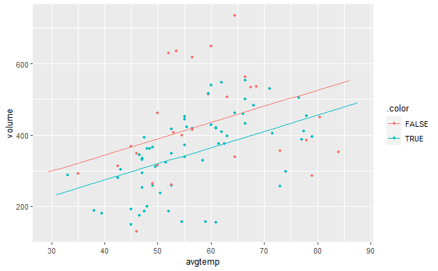

volume = intercept + (b_avg_temp * avgtemp) + (b_weekday * weekday)

when weekday is FALSE

y = intercept

volume = intercept + (b_avg_temp * avgtemp)

## Task - 5 min

try adding the summer categorical prodictor to the existing model with avg temp and weekday

How many lines do you expect to see in the model

```r
summary(model_temp_wday_summer)
```

```
Call:
lm(formula = volume ~ avgtemp + weekday + summer, data = railtrail_trim)

Residuals:
     Min       1Q   Median       3Q      Max
-236.165  -75.448    6.184   68.496  252.680

Coefficients:
            Estimate Std. Error t value Pr(>|t|)
(Intercept)   71.376     90.336   0.790 0.431630
avgtemp        6.387      1.639   3.898 0.000192 ***
weekdayTRUE  -66.958     25.505  -2.625 0.010244 *
summerTRUE   -59.977     41.052  -1.461 0.147662
---
Signif. codes:  0 ‘***’ 0.001 ‘**’ 0.01 ‘*’ 0.05 ‘.’ 0.1 ‘ ’ 1

Residual standard error: 111.1 on 86 degrees of freedom
Multiple R-squared:  0.2659,    Adjusted R-squared:  0.2402
F-statistic: 10.38 on 3 and 86 DF,  p-value: 6.714e-06
```

We’re not going to include summer (at this point) - b/c it isn’t statistically significant

| cor(summer, avgtemp) |
| --- |
| 0.7687716 |

## Interactions

Sometimes there will be a dependency between your ‘independent’ predictors.

Back to our second model: with avgtemp and weekday

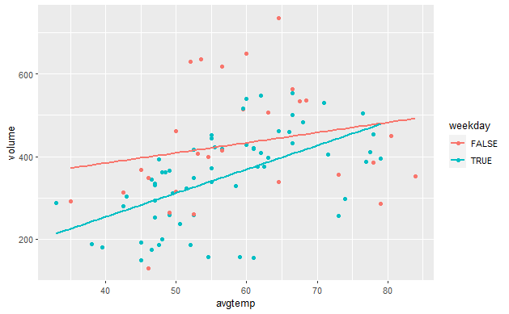

The lines of best fit are different for avgtemp vs volume for the different weekday levels

volume ~ avgtemp + weekday + avgtemp:weekday

volume depends on avg temp, weekday, and the dependency of avgtemp on a weekday

It depends… what does an increase in avg temp have on volume? It depends on whether its a weekday or not.

```r
summary(model_temp_wday_interTW)
```

```
Call:
lm(formula = volume ~ avgtemp + weekday + avgtemp:weekday, data = railtrail_trim)

Residuals:
     Min       1Q   Median       3Q      Max
-269.906  -78.862    2.064   68.190  291.641

Coefficients:
                    Estimate Std. Error t value Pr(>|t|)
(Intercept)          285.887    103.390   2.765  0.00696 **
avgtemp                2.457      1.718   1.431  0.15619
weekdayTRUE         -262.193    128.181  -2.045  0.04386 *
avgtemp:weekdayTRUE    3.300      2.161   1.527  0.13040
---
Signif. codes:  0 ‘***’ 0.001 ‘**’ 0.01 ‘*’ 0.05 ‘.’ 0.1 ‘ ’ 1

Residual standard error: 111 on 86 degrees of freedom
Multiple R-squared:  0.2675,    Adjusted R-squared:  0.2419
F-statistic: 10.47 on 3 and 86 DF,  p-value: 6.115e-06
```

Can read the ‘:’ as “interacting with”

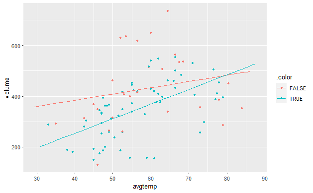

If weekday is true: volume = 285 + 2 * avgtemp - 262 + 3.3 * avgtemp

```r
285.8 + 2.5 * 50 - 262 + 3.3 * 50
```

```
[1] 313.8
```

If weekday is false

intercept + b_avgtemp * avgtemp

```r
285.8 + 2.5 * 50
```

```
[1] 410.8
```

(forgetting about our continuous and categorical interaction for the moment)

## Multiple continuous variables

Add cloudcover to our model

volume = b_avgtemp * avgtemp + b_weekday * weekday + b_cloudcover * cloudcover

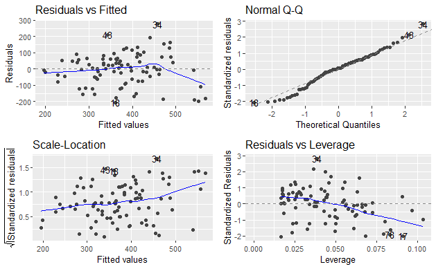

```r
model3_terms <- lm(volume ~ avgtemp + weekday + cloudcover,
                   data = railtrail_trim)

autoplot(model3_terms)
```

```r
summary(model3_terms)
```

```
Call:
lm(formula = volume ~ avgtemp + weekday + cloudcover, data = railtrail_trim)

Residuals:
     Min       1Q   Median       3Q      Max
-204.803  -58.375    6.594   60.178  277.581

Coefficients:
            Estimate Std. Error t value Pr(>|t|)
(Intercept) 200.1022    59.1826   3.381  0.00109 **
avgtemp       5.2461     0.9536   5.502 3.81e-07 ***
weekdayTRUE -47.9480    23.4061  -2.049  0.04356 *
cloudcover  -16.0115     3.3952  -4.716 9.21e-06 ***
---
Signif. codes:  0 ‘***’ 0.001 ‘**’ 0.01 ‘*’ 0.05 ‘.’ 0.1 ‘ ’ 1

Residual standard error: 100.3 on 86 degrees of freedom
Multiple R-squared:  0.4022,    Adjusted R-squared:  0.3814
F-statistic: 19.29 on 3 and 86 DF,  p-value: 1.185e-09
```

A bit more progress r2 shows that the model with avgtemp, weekday and cloudcover explains 40% of the variation in volume of trail users.

SE has reduced to 100 users.

Interpreting our results:

For a 1 degree increase in temperature, we expect 5.2 more users in volume on the trail (holding all other variables constant).

For a 40 degree, 5 cloudy weekday, we expect:

```r
200 - 48 + 5.25 * 40 + 5 * (-16)
```

```
[1] 282
```

282 users

### Task - 5 min

Add precip (daily precipitation in inches) into the regression model. Perform diagnostics, and if you find that precip is a significant predictor, interpret its fitted coefficient.

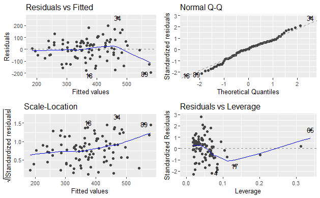

## Interactions between continuous predictors

Incorporate the interaction between avgtemp and precip

volume on the railtrail is dependent on avgtemp, but that relationship might change due to whether its raining or not.

```r
summary(model_4_terms_with_interaction)
```

```
Call:
lm(formula = volume ~ avgtemp + weekday + cloudcover + precip +
    avgtemp:precip, data = railtrail_trim)

Residuals:
     Min       1Q   Median       3Q      Max
-218.775  -59.164    3.183   57.361  266.189

Coefficients:
                Estimate Std. Error t value Pr(>|t|)
(Intercept)     153.9280    63.9007   2.409 0.018189 *
avgtemp           5.8964     1.0598   5.564 3.08e-07 ***
weekdayTRUE     -45.8527    22.7365  -2.017 0.046921 *
cloudcover      -12.8866     3.6984  -3.484 0.000786 ***
precip         -100.8213   353.3547  -0.285 0.776097
avgtemp:precip   -0.2335     4.8893  -0.048 0.962023
---
Signif. codes:  0 ‘***’ 0.001 ‘**’ 0.01 ‘*’ 0.05 ‘.’ 0.1 ‘ ’ 1

Residual standard error: 97.29 on 84 degrees of freedom
Multiple R-squared:  0.4501,    Adjusted R-squared:  0.4173
F-statistic: 13.75 on 5 and 84 DF,  p-value: 8.34e-10
```

Actually, adding in this interaction has reduced the significance of some terms in our model.

```r
avgtemp <- 40
cloudcover <- 5
precip <- c(0, 0.5, 1)
weekday <- TRUE

volume_estimate <- 154 + 5.8 * avgtemp + (-46 * weekday) + (-12 * cloudcover) +
  (-101 * precip) + (-0.2 * avgtemp * precip)
```

Check interaction plots to see if there is an effect.

[figure not shown]

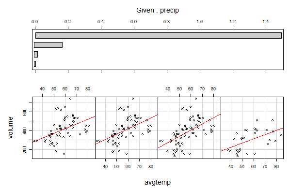

```r
coplot(volume ~ avgtemp | precip, data = railtrail_trim, rows = 1,
       panel = function(x, y, ...){
         points(x, y)
         abline(lm(y ~ x), col = "red")
       })
```

The relationship between volume and avg temperature is the same for every level of precipitation It is not likely that there is a significant interaction between avgtemp and precipitation

| cor(precip, avgtemp) |
| --- |
| 0.2725832 |

```r
library(modelr)
#another tool for model assessment
railtrail_trim %>%
  add_predictions(model = model4_terms)
```

[output not shown]

```r
coefs <- model4_terms$coefficients
prediction <- coefs['(Intercept)'] + coefs['avgtemp'] * avgtemp
```